# Real-world Data Wrangling

## 5. Visualizations & Communication

Create at least 6 plots

Bar Chart : Nguyễn Thành Nhân

```python
categorical_columns = ['sex', 'chest_pain', 'fasting_blood_sugar', 'resting_electrocardiographic_results_y', 'exercise_induced_angina', 'slope', 'coronary_arteries', 'thalassemia', 'target']
```

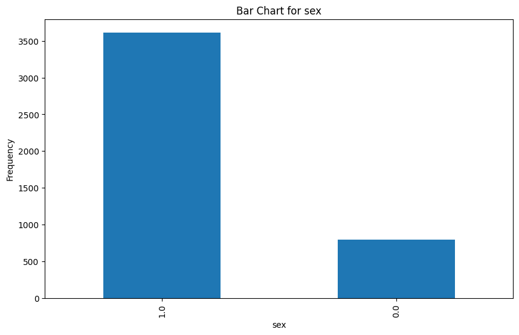

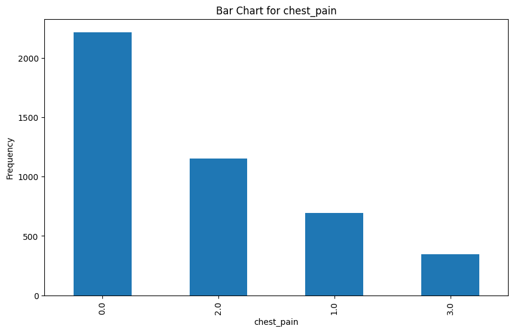

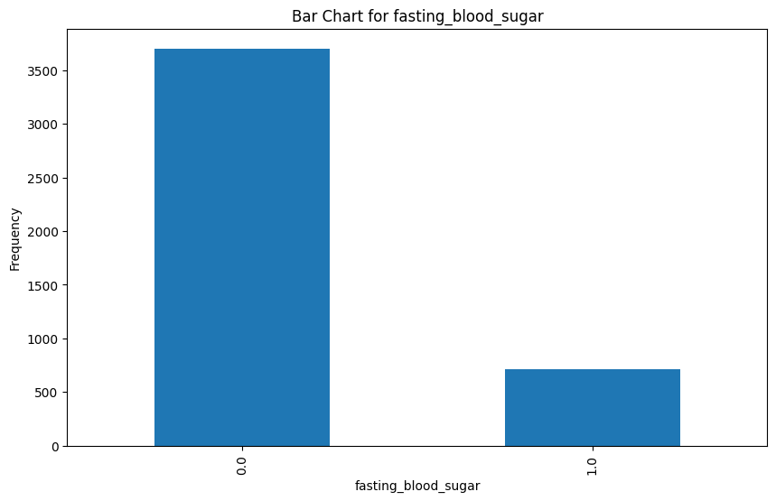

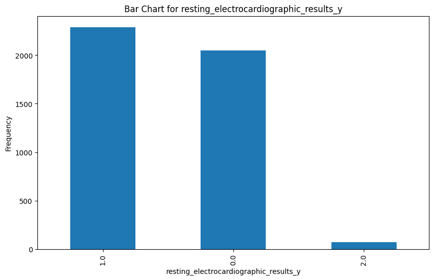

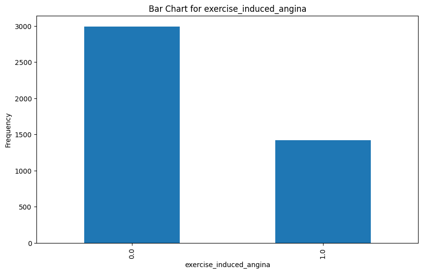

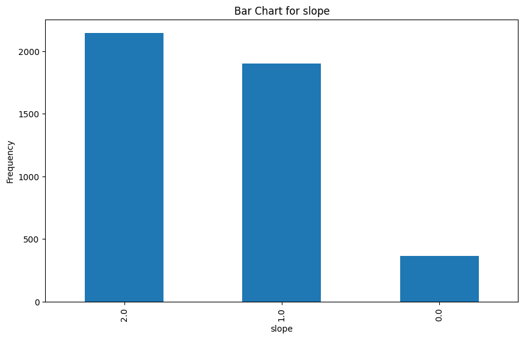

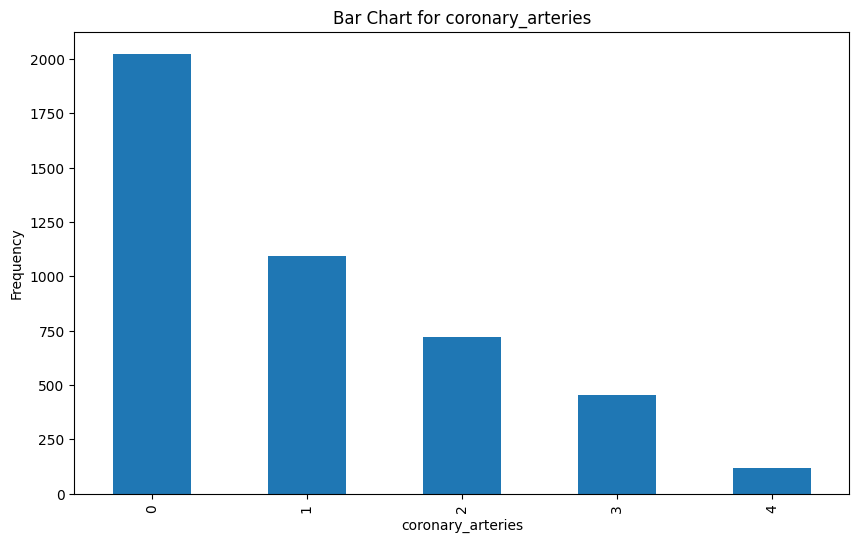

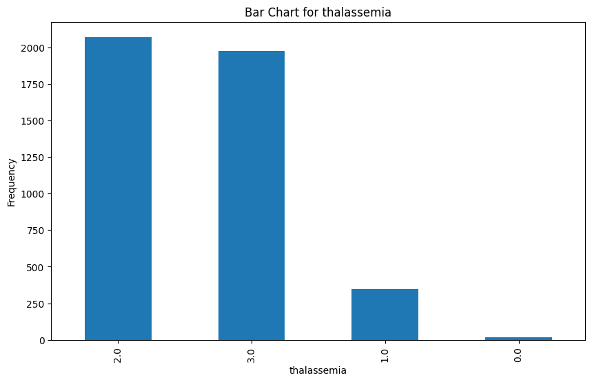

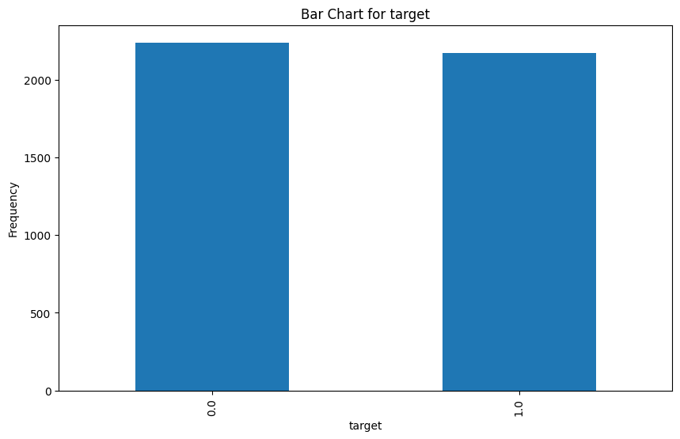

```python
for col in categorical_columns:
    plt.figure(figsize=(10, 6))
    df_merge[col].value_counts().plot(kind='bar')
    plt.title(f'Bar Chart for {col}')
    plt.xlabel(col)
    plt.ylabel('Frequency')
    plt.show()
```

Histogram : Nguyễn Thành Nhân

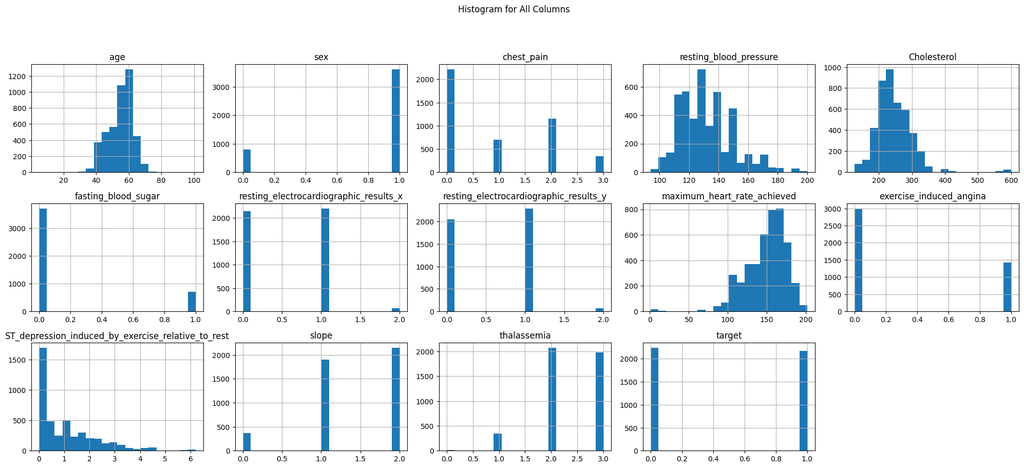

```python
df_merge.hist(bins=20, figsize=(20, 15), layout=(5, 5))
plt.suptitle('Histogram for All Columns')
plt.tight_layout(rect=[0, 0.03, 1, 0.95])
plt.show()
```

Pie Plot : Nguyễn Thành Nhân

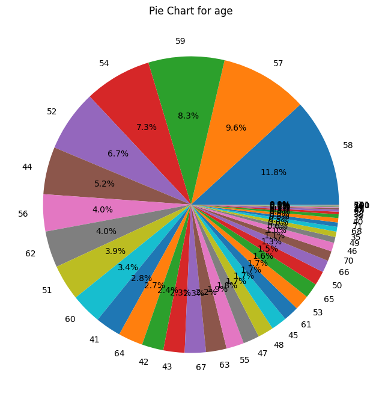

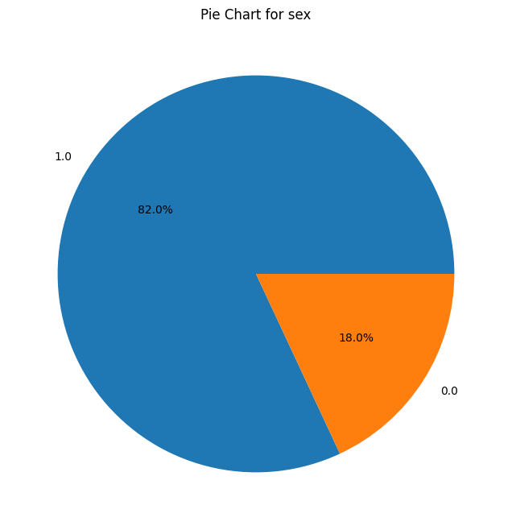

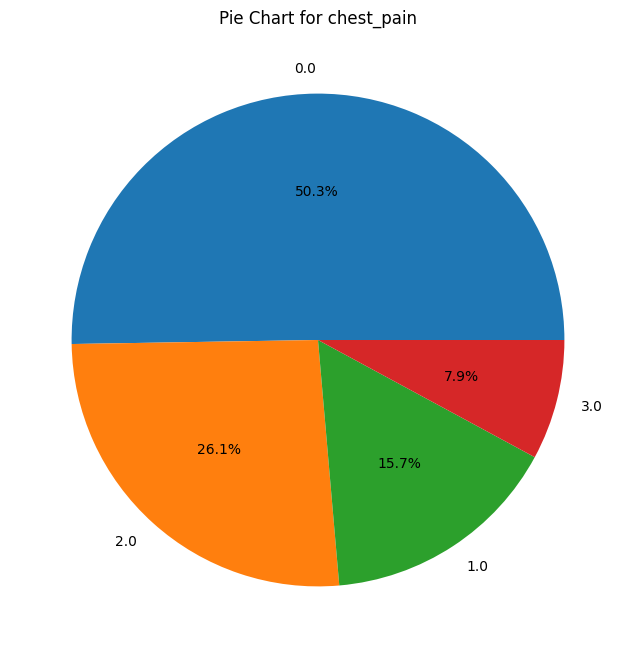

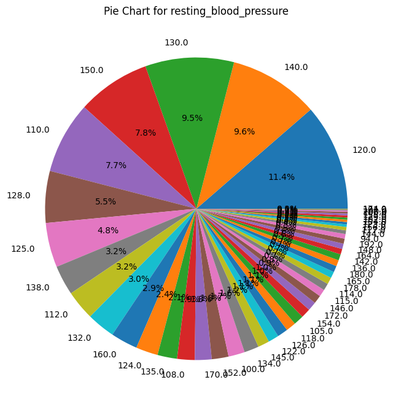

[figure not shown]

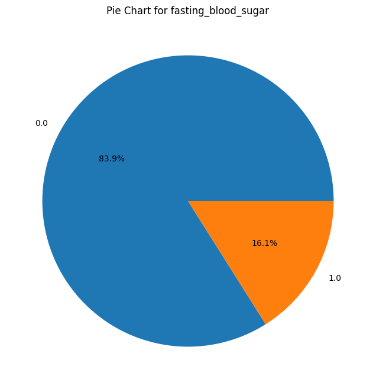

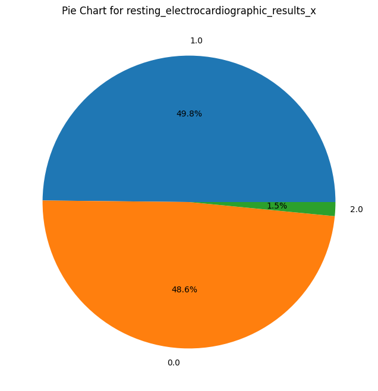

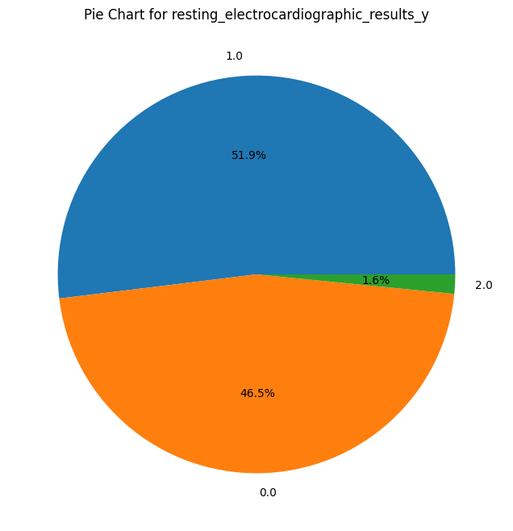

[figure not shown]

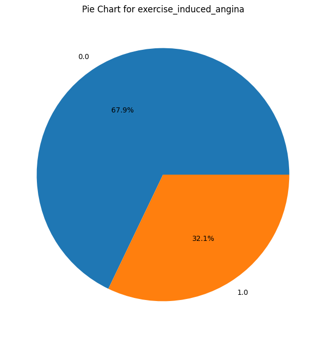

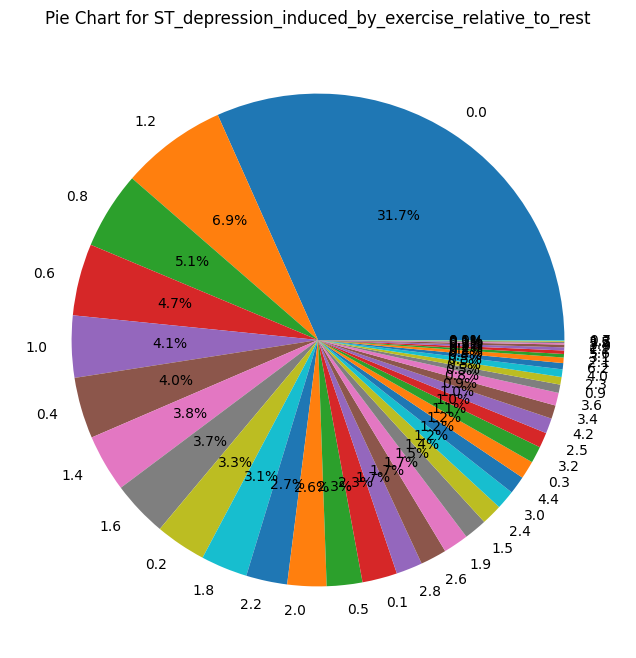

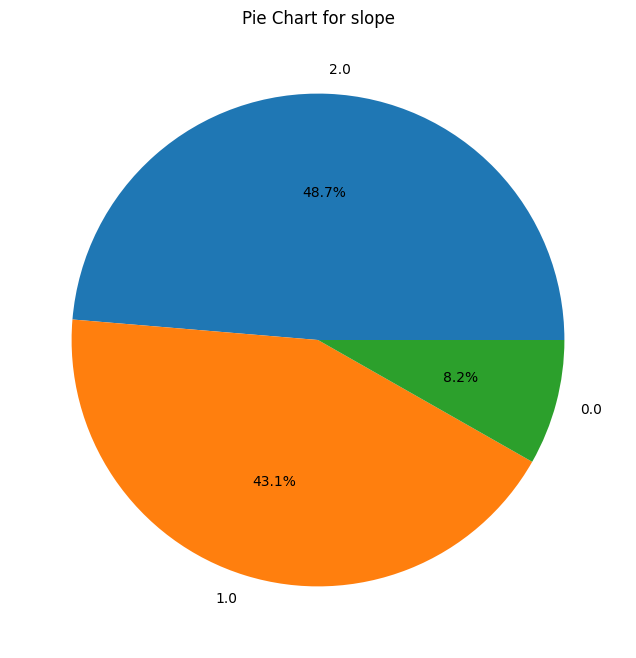

[3 more figures not shown]

```python
for column in df_merge.columns:
    plt.figure(figsize=(8, 8))
    df_merge[column].value_counts().plot(kind='pie', autopct='%1.1f%%')
    plt.title(f'Pie Chart for {column}')
    plt.ylabel('')  # Ẩn nhãn trục y cho biểu đồ tròn
    plt.show()
```

#### SUBMISSION

After completion, export the notebook as an HTML file for the project submission using the File > Download as... > HTML or PDF menu option.

Submit file “my_Project.zip” to Final Project includes:

```
1. my_Project.html
2. my _Project.ipynb
```

## PROJECT 1 STOP HERE

## PROJECT 2

## 6. Answer the research question

### **6.1:** Define and answer the research question

#### Question 1: Dự đoán khả năng mắc bệnh tim thông qua độ tuổi và giới tính - Trường

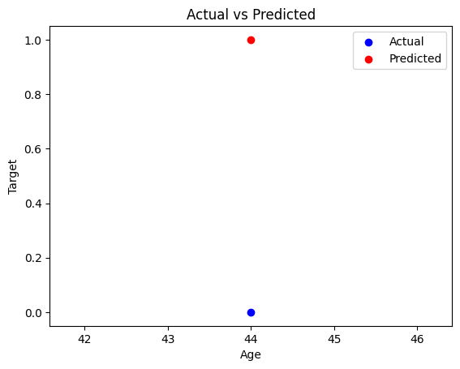

```
Độ chính xác trên tập kiểm tra: 0.0
Xác suất mắc bệnh tim: [0.64933468]
```

```python
# Visual 1 - FILL IN
# Chọn các đặc trưng và biến mục tiêu

features = ['age', 'sex']
target = 'target'

X = df_merge[features]
y = df_merge[target]

# Phân chia dữ liệu thành tập huấn luyện và tập kiểm tra
X_train, X_test, y_train, y_test = train_test_split(X, y, test_size=1, random_state=42)

model = LogisticRegression()
model.fit(X_train, y_train)

y_pred = model.predict(X_test)

plt.scatter(X_test['age'], y_test, color='blue', label='Actual')

plt.scatter(X_test['age'], y_pred, color='red', label='Predicted')

plt.xlabel('Age')
plt.ylabel('Target')
plt.legend()
plt.title('Actual vs Predicted')
plt.show()

# Đánh giá hiệu suất của mô hình
accuracy = accuracy_score(y_test, y_pred)
print("Độ chính xác trên tập kiểm tra:", accuracy)

new_patient = [[45, 1]]
predicted_probability = model.predict_proba(new_patient)
print("Xác suất mắc bệnh tim:", predicted_probability[:,1])
```

#### Question 2: Có sự khác biệt nào về khả năng mắc bệnh tim giữa nam và nữ không - Trường

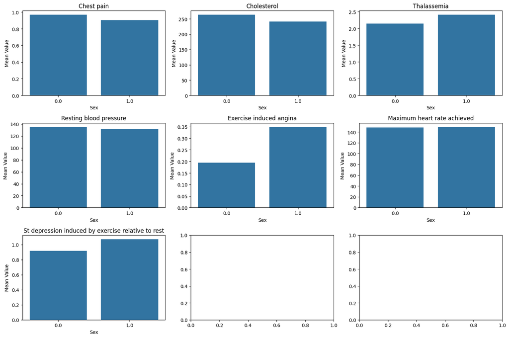

```python
#Visual 2 - FILL IN
# so sánh dạng số
mean_comparison = df_merge.groupby('sex').agg({
    'age': 'mean',
    'chest_pain': 'mean',
    'Cholesterol': 'mean',
    'thalassemia': 'mean',
    'resting_blood_pressure': 'mean',
    'exercise_induced_angina': 'mean',
    'maximum_heart_rate_achieved': 'mean',
    'ST_depression_induced_by_exercise_relative_to_rest': 'mean',
})


attributes = [
                'chest_pain',
                'Cholesterol',
                'thalassemia',
                'resting_blood_pressure',
                'exercise_induced_angina',
                'maximum_heart_rate_achieved',
                'ST_depression_induced_by_exercise_relative_to_rest',
            ]

num_attributes = len(attributes)
num_cols = int(np.ceil(np.sqrt(num_attributes)))
num_rows = int(np.ceil(num_attributes / num_cols))

fig, axes = plt.subplots(nrows=num_cols, ncols=num_rows, figsize=(15, 10))
for i, attr in enumerate(attributes):
    row = i // 3
    col = i % 3
    sns.barplot(x='sex', y=attr, data=mean_comparison, ax=axes[row, col])
    axes[row, col].set_title(attr.replace('_', ' ').capitalize())
    axes[row, col].set_xlabel('Sex')
    axes[row, col].set_ylabel('Mean Value')
plt.tight_layout()
plt.show()
```

#### Question 3: Độ tuổi nào có tỉ lệ mắc bệnh tim cao nhất? (Nguyễn Thành Nhân)

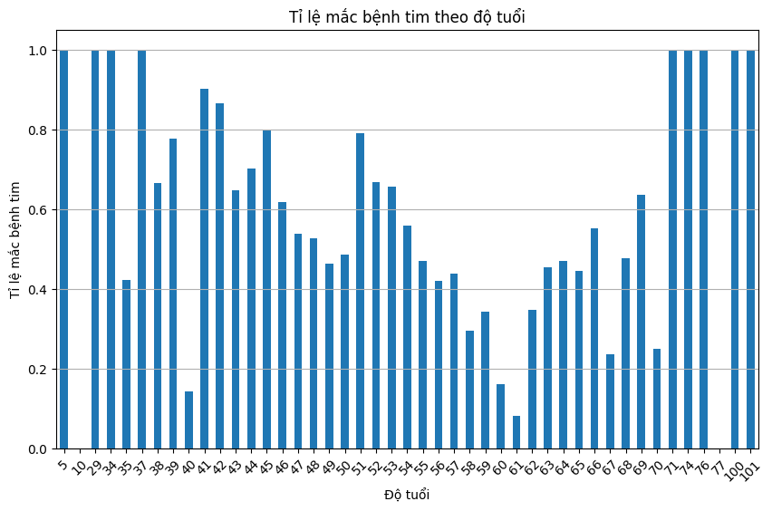

```python
# Tính tỉ lệ mắc bệnh tim theo độ tuổi
age_target_ratio = df_merge.groupby('age')['target'].mean()

# Vẽ biểu đồ cột
plt.figure(figsize=(10, 6))
age_target_ratio.plot(kind='bar')
plt.title('Tỉ lệ mắc bệnh tim theo độ tuổi')
plt.xlabel('Độ tuổi')
plt.ylabel('Tỉ lệ mắc bệnh tim')
plt.xticks(rotation=45)
plt.grid(axis='y')
plt.show()
```

Justifications: Ta thấy phần đầu và cuối có tỉ lệ mắc bệnh tim cao nhất (1.0) và có trường hợp đặc biệt là 5 tuổi đã mắc bệnh tim thì có nguy cơ là do bẩm sinh. Ngược lại, giai đoạn từ 56 - 61 tuổi có tỉ lệ mắc bệnh tim giảm từ dưới 0.5 giảm xuống dưới 0.1 và từ 61 tuổi trở đi thì có xu hướng tăng lên lại.

#### Question 4: Loại đau ngực (cp) nào có tỉ lệ mắc bệnh tim cao nhất (Nguyễn Thành Nhân)

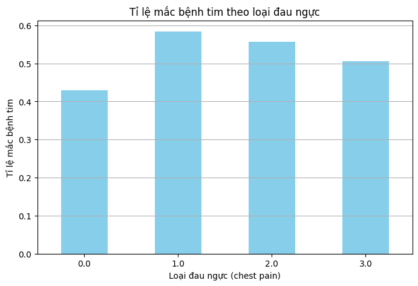

```python
# Tính tỉ lệ mắc bệnh tim theo loại đau ngực
cp_target_ratio = df_merge.groupby('chest_pain')['target'].mean()

# Vẽ biểu đồ cột
plt.figure(figsize=(8, 5))
cp_target_ratio.plot(kind='bar', color='skyblue')
plt.title('Tỉ lệ mắc bệnh tim theo loại đau ngực')
plt.xlabel('Loại đau ngực (chest pain)')
plt.ylabel('Tỉ lệ mắc bệnh tim')
plt.xticks(rotation=0)
plt.grid(axis='y')
plt.show()
```

Justifications: ta thấy loại đau ngược 1 có tỉ lệ mắc bệnh tim cao nhất với gần 0.6. ngược lại thì 0 đau ngực có tỉ lệ thấp nhất với chỉ hơn 0.4

#### Question 5: Nhịp tim tối đa đạt được của người có bệnh tim và người không có bệnh tim là bao nhiêu? (Trương Hoàng Quốc Đạt)

```
No artists with labels found to put in legend.  Note that artists whose label start with an underscore are ignored when legend() is called with no argument.
```

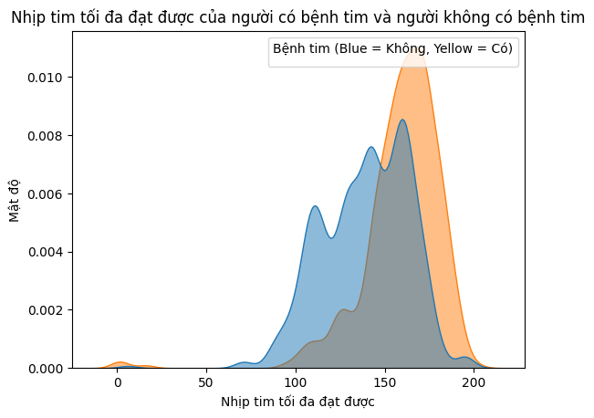

```python
#Biểu đồ KDE biểu thị nhịp tim tối đa đạt được cửa người có bệnh tim và người không có bệnh tim
sns.kdeplot(data=df_merge, x='maximum_heart_rate_achieved', hue='target', fill=True, alpha=0.5)
plt.xlabel('Nhịp tim tối đa đạt được')
plt.ylabel('Mật độ')
plt.title('Nhịp tim tối đa đạt được của người có bệnh tim và người không có bệnh tim')
plt.legend(title='Bệnh tim (Blue = Không, Yellow = Có)')
plt.show()
```

Justifications: ta thấy đối với những người bị bệnh tim thì có nhịp tim tối đa cao hơn những người không bị bệnh tim và những người đó có trên 0.010. Còn những người không bị bệnh tim thì có nhịp tim trung bình thấp hơn với mật độ ít hơn những người bị bệnh tim.

#### Question 6: Sự phân bố về giới tính của những người bị bệnh tim và không bị bệnh tim? (Trương Hoàng Quốc Đạt)

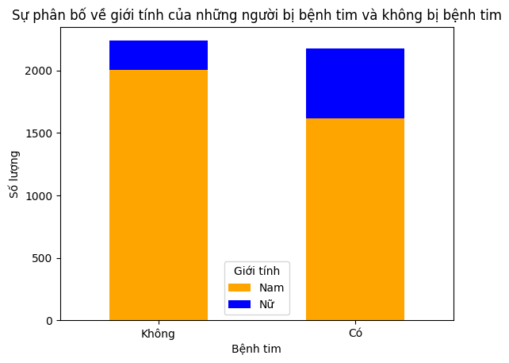

```python
#Sự phân bố về giới tính của những người bị bệnh tim và không bị bệnh tim
# Thay thế giá trị trong cột 'sex'
df_merge['sex'] = df_merge['sex'].replace({0.0: 'Nữ', 1.0: 'Nam'})

# Tính toán sự phân bố giới tính trong từng nhóm bệnh tim
df_grouped = df_merge.groupby(['target', 'sex']).size().unstack()

# Vẽ biểu đồ stacked bar
ax = df_grouped.plot(kind='bar', stacked=True, color=['orange', 'blue'])
plt.xlabel('Bệnh tim')
plt.ylabel('Số lượng')
plt.title('Sự phân bố về giới tính của những người bị bệnh tim và không bị bệnh tim')
plt.legend(title='Giới tính')

# Thay đổi nhãn trục x
ax.set_xticklabels(['Không', 'Có'], rotation=0)
plt.show()
```

### **6.2:** Reflection

#### SUBMISSION

After completion, export the notebook as an HTML file for the project submission using the File > Download as... > HTML or PDF menu option.

Submit file “my_Project.zip” to Final Project includes:

```
1. my_Project.html
2. my _Project.ipynb
```